# HW4 - ATP Tennis Statiistics

Expanded analysis of match statitistics spanning multiple decades of ATP Professional Tennis seasons.

Jason O’Connell  
2022-03-20

## HW4 Overview

This is homework assignment #4 for Jason O’Connell. I have found some interesting data on profession tennis on github and I think I will use this for my final project.

For this homework I will bring in a few data file from various years and try somethings to compare the data between files

## Initialize Libraries

```r
library(tidyverse)
library(readr)
library(readxl)
library(dplyr)
library(ggplot2)
```

## Read the data

First read ATP data files, here I am using only the results from 1980, 1990, 2000, 2010 from GITHUB source

```r
ATP1980 <- read.csv("https://raw.githubusercontent.com/JeffSackmann/tennis_atp/master/atp_matches_1980.csv")
ATP1990 <- read.csv("https://raw.githubusercontent.com/JeffSackmann/tennis_atp/master/atp_matches_1990.csv")
ATP2000 <- read.csv("https://raw.githubusercontent.com/JeffSackmann/tennis_atp/master/atp_matches_2000.csv")
ATP2010 <- read.csv("https://raw.githubusercontent.com/JeffSackmann/tennis_atp/master/atp_matches_2010.csv")
```

## Including Improved HW3 Plot

First I will improve on my visuals from last HW and look at them with the new data from this homework.

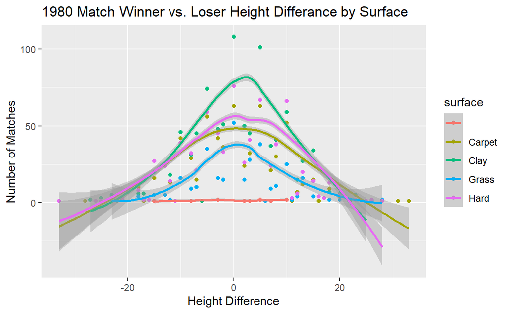

```r
# ATP1980 %>%
#   drop_na(winner_ht, loser_ht) %>%
#   group_by(winner_ht, loser_ht) %>%
#   summarise(winner_ht,loser_ht, count = n())

ATP1980 %>%
  drop_na(winner_ht, loser_ht) %>%
  mutate(ht_diff=winner_ht-loser_ht) %>%
  group_by(surface, ht_diff) %>%
  summarise(surface, ht_diff, count = n()) %>%
  ggplot(aes(x=ht_diff, y=count)) +
    geom_point(aes(color=surface)) +
    geom_smooth(aes(color=surface)) +
    labs(title="1980 Match Winner vs. Loser Height Differance by Surface", x="Height Difference", y="Number of Matches")
```

## Insights

This graphs is a huge improvement over what I was doing in the last HW. Learning geom_smooth() in tutorial 6 really helps. I can quickly see the blank surface data is sort of noise that I should eliminate. Also can see pretty easily the the data is skewed toward the taller player winning but also the more matches are played on clay then hard, then carpet?, and finally grass. I am not sure they even play on carpet anymore - we will check in the 2010 file.

In the other files missing court surface isn’t an issue. Let’e redo 1980 eliminating the missing surface rows and inlcude the other years with the same plot:

## 1980

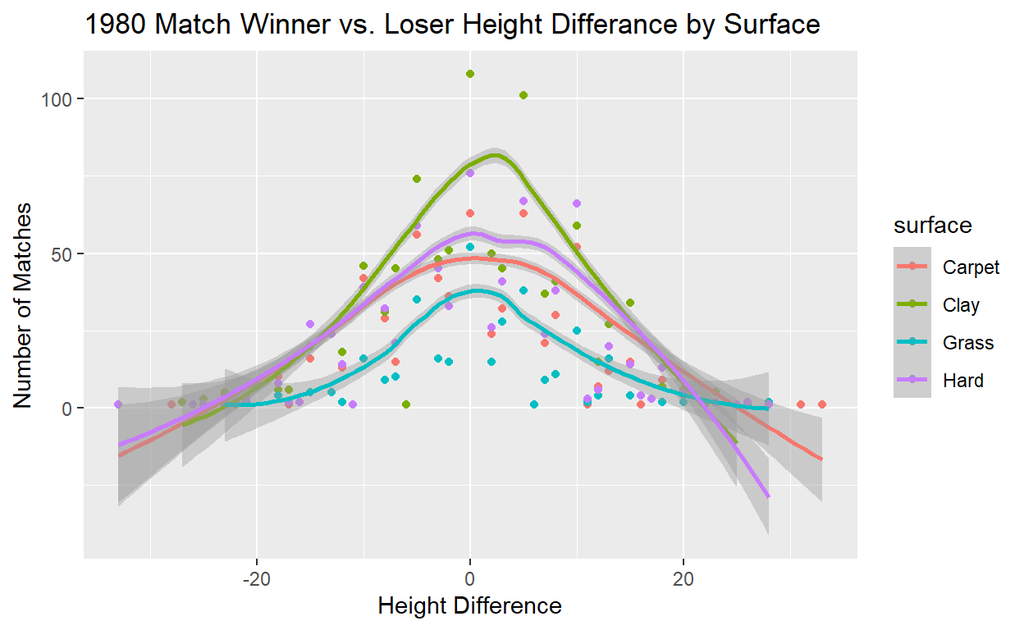

```r
ATP1980 %>%
  drop_na(winner_ht, loser_ht) %>%
  filter(str_detect('Clay|Hard|Carpet|Grass', surface)) %>%
  mutate(ht_diff=winner_ht-loser_ht) %>%
  group_by(surface, ht_diff) %>%
  summarise(surface, ht_diff, count = n()) %>%
  ggplot(aes(x=ht_diff, y=count)) +
    geom_point(aes(color=surface)) +
    geom_smooth(aes(color=surface)) +
    labs(title="1980 Match Winner vs. Loser Height Differance by Surface", x="Height Difference", y="Number of Matches")
```

## 1990

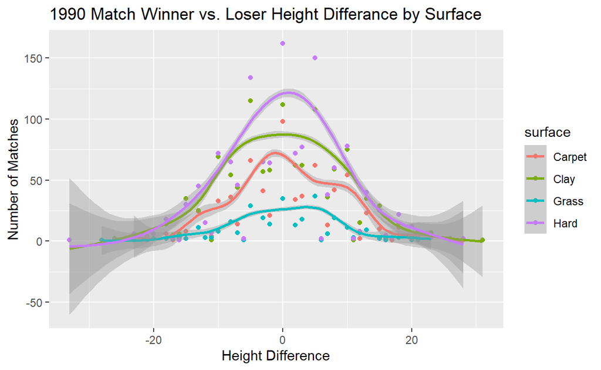

```r
ATP1990 %>%
  drop_na(winner_ht, loser_ht) %>%
  mutate(ht_diff=winner_ht-loser_ht) %>%
  group_by(surface, ht_diff) %>%
  summarise(surface, ht_diff, count = n()) %>%
  ggplot(aes(x=ht_diff, y=count)) +
    geom_point(aes(color=surface)) +
    geom_smooth(aes(color=surface)) +
    labs(title="1990 Match Winner vs. Loser Height Differance by Surface", x="Height Difference", y="Number of Matches")
```

That one looks pretty good.

## 2000

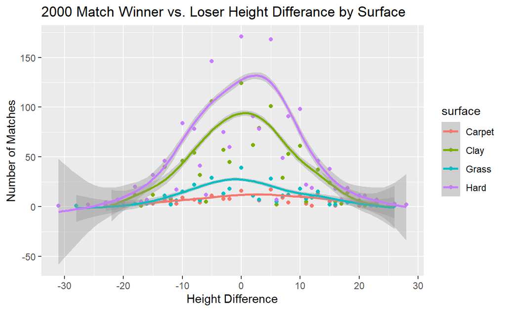

```r
ATP2000 %>%
  drop_na(winner_ht, loser_ht) %>%
  mutate(ht_diff=winner_ht-loser_ht) %>%
  group_by(surface, ht_diff) %>%
  summarise(surface, ht_diff, count = n()) %>%
  ggplot(aes(x=ht_diff, y=count)) +
    geom_point(aes(color=surface)) +
    geom_smooth(aes(color=surface)) +
    labs(title="2000 Match Winner vs. Loser Height Differance by Surface", x="Height Difference", y="Number of Matches")
```

Same for this one.

## 2010

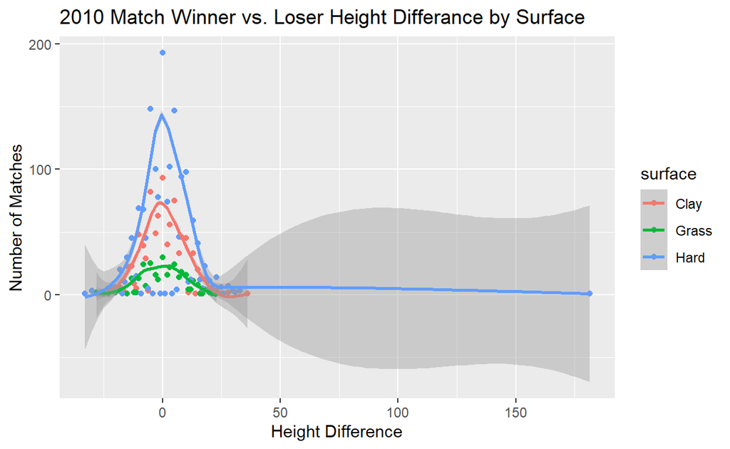

```r
ATP2010 %>%
  drop_na(winner_ht, loser_ht) %>%
  filter(str_detect('Clay|Hard|Grass', surface)) %>%
  mutate(ht_diff=winner_ht-loser_ht) %>%
  group_by(surface, ht_diff) %>%
  summarise(surface, ht_diff, count = n()) %>%
  ggplot(aes(x=ht_diff, y=count)) +
    geom_point(aes(color=surface)) +
    geom_smooth(aes(color=surface)) +
    labs(title="2010 Match Winner vs. Loser Height Differance by Surface", x="Height Difference", y="Number of Matches")
```

Hmmm I’ve got a weird outlier - let’s get rid of that.

## 2010v2

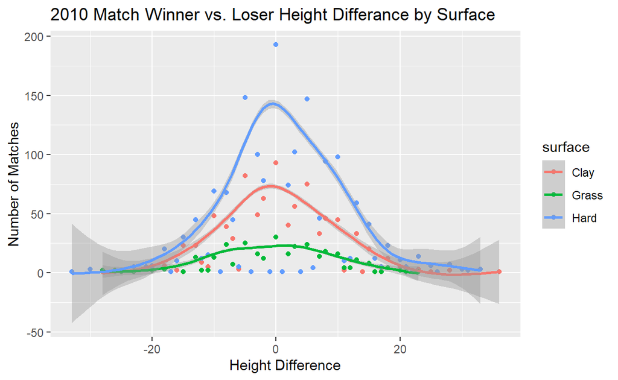

```r
ATP2010 %>%
  drop_na(winner_ht, loser_ht) %>%
  filter(str_detect('Clay|Hard|Grass', surface)) %>%
  mutate(ht_diff=winner_ht-loser_ht) %>%
  filter(ht_diff < 100) %>%
  group_by(surface, ht_diff) %>%
  summarise(surface, ht_diff, count = n()) %>%
  ggplot(aes(x=ht_diff, y=count)) +
    geom_point(aes(color=surface)) +
    geom_smooth(aes(color=surface)) +
    labs(title="2010 Match Winner vs. Loser Height Differance by Surface", x="Height Difference", y="Number of Matches")
```

## Combine the data and compare years

Now I will combine the data sets and see what it looks like over the decades. First let’s look at the violin chart.

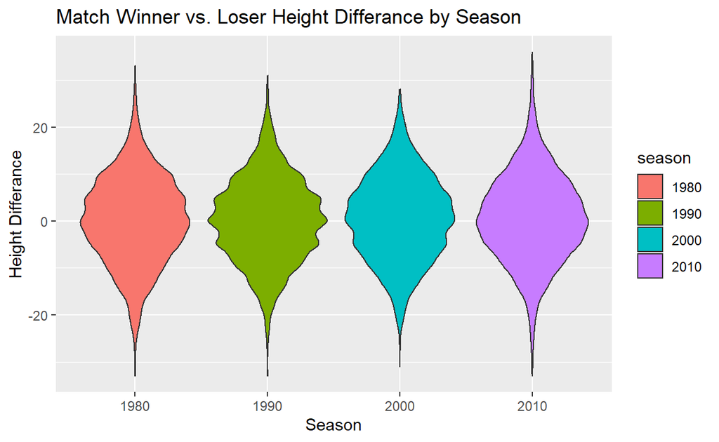

```r
bind_rows(mutate(ATP1980,season = "1980"),mutate(ATP1990, season = "1990"), mutate(ATP2000, season = "2000"), mutate(ATP2010, season = "2010")) %>%
  drop_na(winner_ht, loser_ht) %>%
  mutate(ht_diff=winner_ht-loser_ht) %>%
  filter(ht_diff < 100) %>%
  group_by(season, ht_diff) %>%
  summarise(season, ht_diff, count = n()) %>%
  ggplot(aes(x=season, y=ht_diff, fill=season)) +
    geom_violin() +
    labs(title="Match Winner vs. Loser Height Differance by Season", x="Season", y="Height Differance")
```

## Combined Data Files - Second try

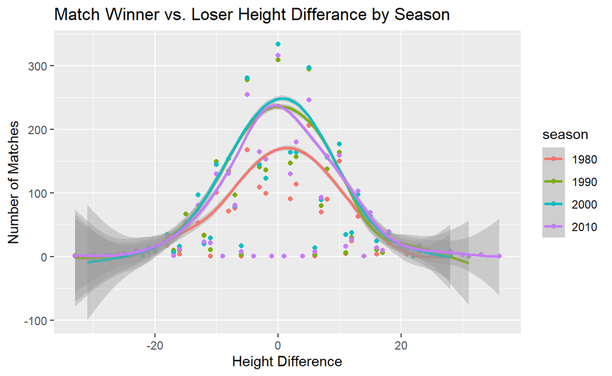

```r
bind_rows(mutate(ATP1980,season = "1980"),mutate(ATP1990, season = "1990"), mutate(ATP2000, season = "2000"), mutate(ATP2010, season = "2010")) %>%
  drop_na(winner_ht, loser_ht) %>%
  filter(str_detect('Clay|Hard|Grass', surface)) %>%
  mutate(ht_diff=winner_ht-loser_ht) %>%
  filter(ht_diff < 100) %>%
  group_by(season, ht_diff) %>%
  summarise(season, ht_diff, count = n()) %>%
  ggplot(aes(x=ht_diff, y=count)) +
    geom_point(aes(color=season)) +
    geom_smooth(aes(color=season)) +
    labs(title="Match Winner vs. Loser Height Differance by Season", x="Height Difference", y="Number of Matches")
```